# **IE360 Homework1**

Eylul Kepcen

April 13th, 2022

### **Introduction**

In our everyday lives, we encounter different types of economical issues. Especially in an economically unstable country like Turkey, society faces many problems affecting their working, social, and private lives. Those problems may have impact on each other, meaning that a change in a variable may affect other ones. These changes could be in any ways, positive or negative, in any time, over a short or a long run. This study’s aim is to understand some of those relations. As three variables, I chose:

- Unemployment Rate (%)
- Consumer Price Index (CPI)
- Housing Unit Price (TL/m2) in Turkey.

The Consumer Price Index (CPI) is defined as the measure that examines the weighted average of prices of a basket of consumer goods and services, such as transportation, food, and medical care. It is the **general** CPI that I chose, including all other parameters in itself, as mentioned.

As a first glance, I think that CPI and Housing Unit Price should have a positive correlation, but not a strong one because CPI includes many parameters, not only housing. Unemployment rate may also be correlated with the other two variables. I will learn the exact relationships when I apply the tests, analysis, and visualizations.

The research question of this study is: **How much do CPI, Unemployment Rate, and Housing Unit Price have correlation between them?**

My motivation to study especially these variables is that I think it will ease my understanding of some economic aspects of daily life in Turkey.

### **Reading the data**

Required libraries are added and the data file (.xlsx) is read using the read_excel function.

```r
library(ggplot2)
library(ggfortify)
library(xts)
library(ggcorrplot)
library(readxl)
library(GGally)

EVDS_new <- read_excel("C:\\Users\\eylulkepcen\\Downloads\\EVDS_data.xlsx")
```

After reading the data from the Excel file, some manipulations are made. To demonstrate the three data sets in the same line graph, some numerical divisions are made. Column names are edited for good readability and aesthetic, and the data is transformed to a time series data, as well.

```r
colnames(EVDS_new) = c("Date","UnemploymentRate", "CPI", "HousingUnitPrice")
EVDS_new[,4] <- EVDS_new[,4]/100
EVDS_new[,3] <- EVDS_new[,3]/10
EVDS_new[,2] <- EVDS_new[,2]/1

EVDS_new$Date <- as.yearmon(x = EVDS_new$Date)
EVDS_time <- xts(x = EVDS_new[-1],order.by = EVDS_new$Date, frequency = 12)

colnames(EVDS_time) <- c("UnemploymentRate", "CPI", "HousingUnitPrice")
```

### **Data Visualization**

Using newly created time series data, a line chart is plotted where we can observe all three data sets’ motions over the last eight years.

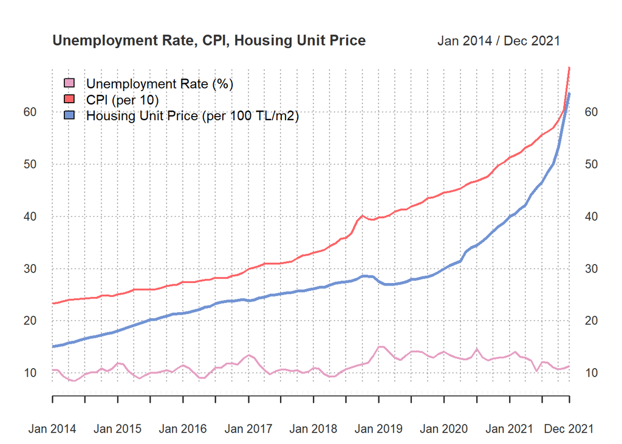

```r
colors = c("#E6A0C4", "#FD6467", "#7294D4")
colnames <- colnames(EVDS_time)
parameters <- c("Unemployment Rate (%)", "CPI (per 10)", "Housing Unit Price (per 100 TL/m2)")
colnames(EVDS_time) <- parameters

plot(x = EVDS_time, ylab = "", main = "Unemployment Rate, CPI, Housing Unit Price",
     col = colors, lwd = c(2,2,3),legend.loc = "topleft", minor.ticks = "years",
     grid.ticks.on = "quarter", grid.ticks.lty = "dotted")
```

Looking at the data, we can make comments about how they change over years.

- Unemployment Rate tends to have a stationary motion.
- CPI and Housing Unit Prices have an increasing trend. Their increases are rather similar with each other than the Unemployment Rate.

Then some additional manipulations are made, as well. Date formatting and creating independent data frames for each data set are done.

```r
colnames(EVDS_time) <- c("UnemploymentRate", "CPI", "HousingUnitPrice")

EVDS_new$Year <- as.Date(x = EVDS_new$Date, format = "%m %Y")
EVDS_new$Year <- substr(EVDS_new$Year, 0, 4)

EVDS_Unemp <- EVDS_new[,c(1,2,5)]
EVDS_CPI <- EVDS_new[,c(1,3,5)]
EVDS_House <- EVDS_new[,c(1,4,5)]
```

Histograms of Unemployment Rate, CPI, and Housing Unit Price over eight years (2014-2021) are plotted. They will help us visualize the data and give us some idea about them.

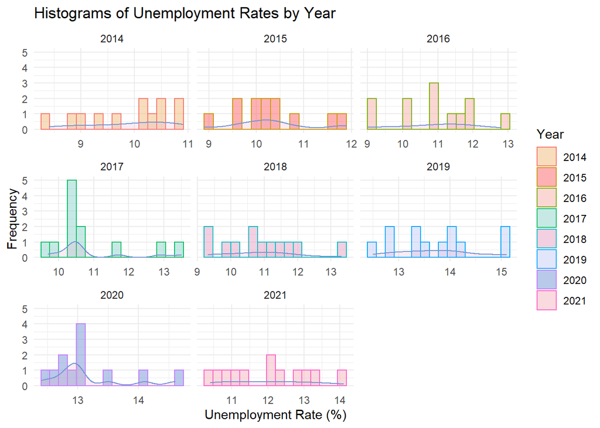

```r
#Unemployment
ggplot(data = EVDS_Unemp,aes(x = UnemploymentRate)) +
  geom_histogram(bins = 16, alpha = 0.5,aes(color = Year, fill = Year)) +
  geom_density(alpha=.2, fill="#E6A0C4", colour="#7294D4") +
  facet_wrap(facets = .~Year,scales = "free_x",nrow=3) +
  scale_fill_manual(values=c("#F1BB7B", "#FD6467", "#F8AFA8","#90D4CC", "#E6A0C4", "#C6CDF7", "#7294D4","#F4B5BD")) +
  labs(title = "Histograms of Unemployment Rates by Year",
       x = "Unemployment Rate (%)",
       y = "Frequency") +
  theme_minimal()
```

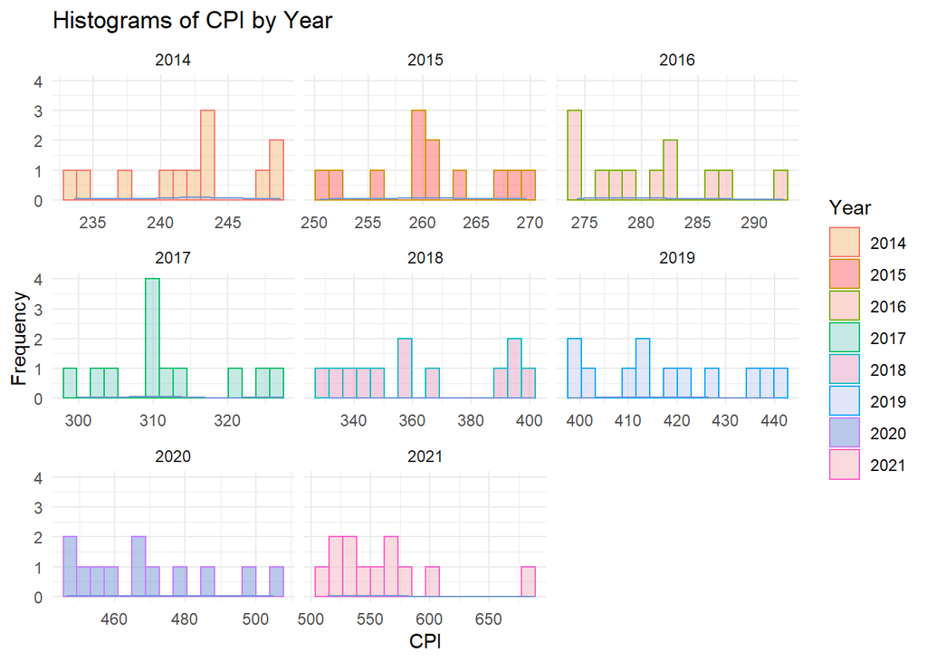

```r
#CPI
ggplot(data = EVDS_CPI,aes(x = CPI*10)) +
  geom_histogram(bins = 16, alpha = 0.5,aes(color = Year, fill = Year)) +
  geom_density(alpha=.2, fill="#E6A0C4", colour="#7294D4") +
  facet_wrap(facets = .~Year,scales = "free_x",nrow=3) +
  scale_fill_manual(values=c("#F1BB7B", "#FD6467", "#F8AFA8","#90D4CC", "#E6A0C4", "#C6CDF7", "#7294D4","#F4B5BD")) +
  labs(title = "Histograms of CPI by Year",
       x = "CPI",
       y = "Frequency") +
  theme_minimal()
```

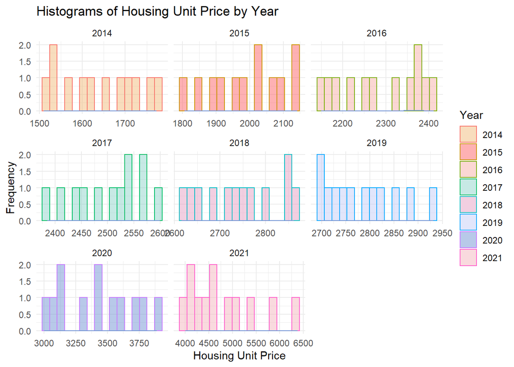

```r
#Housing
ggplot(data = EVDS_House,aes(x = HousingUnitPrice*100)) +
  geom_histogram(bins = 16, alpha = 0.5,aes(color = Year, fill = Year)) +
  geom_density(alpha=.2, fill="#E6A0C4", colour="#7294D4") +
  facet_wrap(facets = .~Year,scales = "free_x",nrow=3) +
  scale_fill_manual(values=c("#F1BB7B", "#FD6467", "#F8AFA8","#90D4CC", "#E6A0C4", "#C6CDF7", "#7294D4","#F4B5BD")) +
  labs(title = "Histograms of Housing Unit Price by Year",
       x = "Housing Unit Price",
       y = "Frequency") +
  theme_minimal()
```

Now we have three different data sets’ histograms, being grouped according to their year axis. Their frequencies, yearly distributions, and rates can be seen at one glance. Hence, it becomes easier to make a comment on their behavior.

- For CPI and Housing Unit Price, each year data interval changes because of the increasing trend. We can comment on their behavior within a year. Also by looking at the x-axis, we can say that it tends to increase each year.
- For Unemployment Rate, data intervals of the histograms tend to be more stationary. They don’t have dramatic changes every year, leading us to think that unemployment rate has a stationary behavior over years.

After making more manipulation and correction on date format, a box plot that visualizes all three data sets are plotted. This box plot will represent their independent behaviors and their relationships with each other over years.

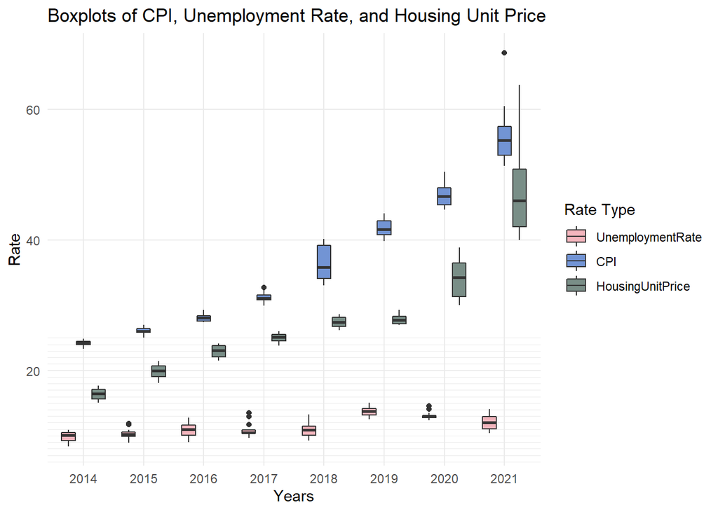

```r
#Boxplot

data = EVDS_new[,1:4]

data_stacked <- cbind("Date" = as.yearmon(rep(data$Date,3)), stack(data))
years <- factor(format(data$Date, format = "%Y"),ordered = TRUE)
data_stacked$Year <- rep(years,3)
ggplot(data = data_stacked,mapping = aes(x = Year,y = values)) +
  geom_boxplot(mapping = aes(fill = ind)) +
  scale_fill_manual(values=c("#F4B5BD", "#7294D4","#798E87")) +
  labs(title = "Boxplots of CPI, Unemployment Rate, and Housing Unit Price",
       x = "Years", "Rate (TRY/%)",
       y = "Rate",
       fill = "Rate Type") +
  scale_y_continuous(minor_breaks = seq(0,25,by = 1)) +
  theme_minimal()
```

Similar to the line graph plotted before, it is easy to observe the trend and stationary behaviors. CPI, and being followed by Housing Unit Prices, seem to be increasing together over years. Moreover, we also see that their data intervals are very much wide in 2021. Hence, they have more deviation in 2021, compared to previous years. This was one thing that we couldn’t easily observe in line graph.

### **Correlation Study**

Using cor.test function, correlation tests are performed for groups of two. By analyzing the numerical results of correlation statistics, we can make more exact comments.

```r
#Correlation test
cor.test(x = EVDS_time$UnemploymentRate, y = EVDS_time$CPI, method = "pearson", alternative = "greater")
```

```
##
##  Pearson's product-moment correlation
##
## data:  EVDS_time$UnemploymentRate and EVDS_time$CPI
## t = 6.6919, df = 94, p-value = 7.894e-10
## alternative hypothesis: true correlation is greater than 0
## 95 percent confidence interval:
##  0.4414786 1.0000000
## sample estimates:
##       cor
## 0.5680433
```

Correlation test for **Unemployment Rate & CPI** shows us that the p-value is 7.894e-10 which is significantly lower than 0.05, so we reject the null hypothesis which states that correlation coefficient is equal to zero. Unemployment Rate and CPI has a positive correlation with a correlation coefficient equal to 0.5680433.

```r
cor.test(x = EVDS_time$UnemploymentRate, y = EVDS_time$HousingUnitPrice, method = "pearson", alternative = "greater")
```

```
##
##  Pearson's product-moment correlation
##
## data:  EVDS_time$UnemploymentRate and EVDS_time$HousingUnitPrice
## t = 4.1551, df = 94, p-value = 3.581e-05
## alternative hypothesis: true correlation is greater than 0
## 95 percent confidence interval:
##  0.2410282 1.0000000
## sample estimates:
##       cor
## 0.3939176
```

Correlation test for **Unemployment Rate & Housing Unit Price** shows us that the p-value is 3.581e-05 which is significantly lower than 0.05, so we reject the null hypothesis which states that correlation coefficient is equal to zero. Unemployment Rate and Housing Unit Price has a positive correlation with a correlation coefficient equal to 0.3939176. This is rather a weak correlation among all correlations.

```r
cor.test(x = EVDS_time$CPI, y = EVDS_time$HousingUnitPrice, method = "pearson", alternative = "greater")
```

```
##
##  Pearson's product-moment correlation
##
## data:  EVDS_time$CPI and EVDS_time$HousingUnitPrice
## t = 31.243, df = 94, p-value < 2.2e-16
## alternative hypothesis: true correlation is greater than 0
## 95 percent confidence interval:
##  0.937376 1.000000
## sample estimates:
##       cor
## 0.9550697
```

Correlation test for **Housing Unit Price & CPI** shows us that the p-value is smaller than 2.2e-16 which is significantly lower than 0.05, so we reject the null hypothesis which states that correlation coefficient is equal to zero. CPI and Housing Unit Price has a positive correlation with a correlation coefficient equal to 0.9550697. This is very much a strong correlation leads us to think that they have big impacts on each other, having similar behaviors over time.

Correlation matrix is plotted to visualize the correlation coefficients which calculated before:

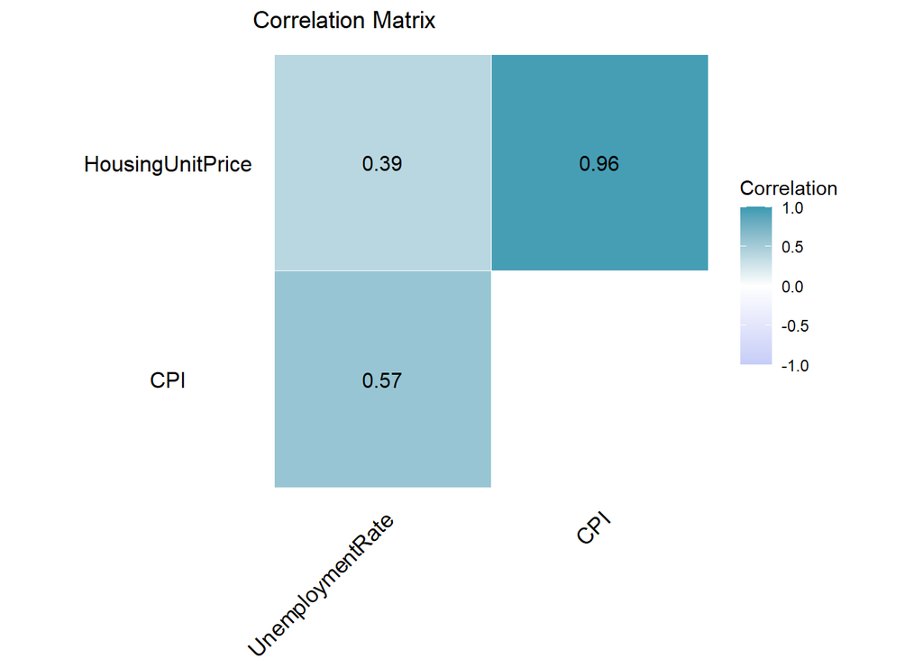

```r
ggcorrplot(corr = cor(EVDS_time),
           hc.order = TRUE,
           outline.col = "white",
           type = "upper",lab = TRUE,
           title = "Correlation Matrix",
           colors = c("#C6CDF7", "white","#3B9AB2"),
           legend.title = "Correlation",
           ggtheme = theme_void)
```

As we had seen from the statistical results, there are three coefficients that we can comment on:

- 0.39 (Unemployment Rate & Housing Unit Price)
- 0.57 (Unemployment Rate & CPI)
- 0.95 (Housing Unit Price & CPI)

Highlights of these results are: Unemployment Rate and Housing Unit Price have weaker correlation than others, and most importantly, Housing Unit Price and CPI have a correlation coefficient being almost equal to 1.

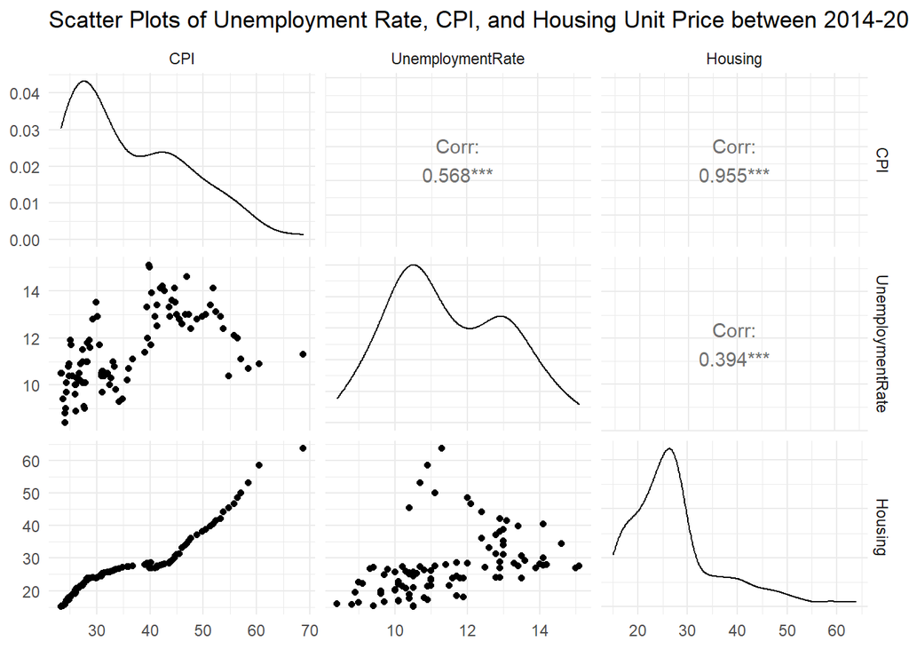

```r
pairs = data.frame(rand=NA)
pairs = cbind(pairs, Date = EVDS_new$Date, CPI = EVDS_new$CPI, UnemploymentRate = EVDS_new$UnemploymentRate, Housing=EVDS_new$HousingUnitPrice)
pairs = pairs[,-1]
ggpairs(pairs[,-1]) + theme_minimal() + labs(title ="Scatter Plots of Unemployment Rate, CPI, and Housing Unit Price between 2014-2021", nrow=3)
```

You can find the scatter plots of data sets grouped by two below:

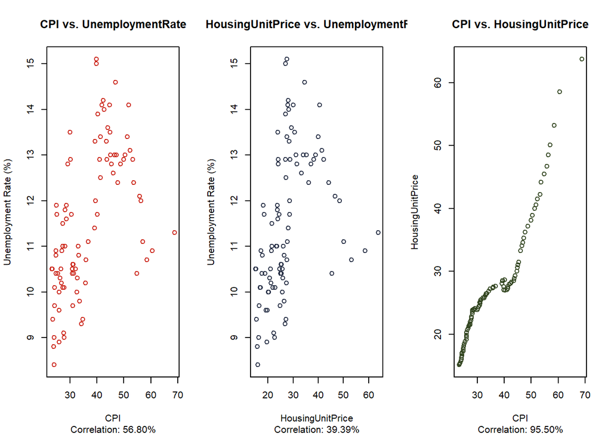

```r
par(mfrow=c(1,3))
plot(x = data$CPI,y = data$UnemploymentRate,
     main = "CPI vs. UnemploymentRate",
     xlab = "CPI", ylab = "Unemployment Rate (%)",
     sub = "Correlation: 56.80%", col="#CB2314")
plot(x = data$HousingUnitPrice,y = data$UnemploymentRate,
     main = "HousingUnitPrice vs. UnemploymentRate",
     xlab = "HousingUnitPrice", ylab = "Unemployment Rate (%)",
     sub = "Correlation: 39.39%", col="#273046")
plot(x = data$CPI,y = data$HousingUnitPrice,
     main = "CPI vs. HousingUnitPrice",
     xlab = "CPI", ylab = "HousingUnitPrice",
     sub = "Correlation: 95.50%", col = "#354823")
```

Those plots are good at visualizing pairwise relationship of data sets. Thanks to their strong correlation, Housing Unit Price and CPI’s scatters overlap almost the entire time.

### **Conclusion**

I now have all statistics info and related graphs for visualization. Hence, it became easier to analyse the data quantitatively.

Even though I had thought CPI and Housing Unit Price have relatively weak correlation, the results show that they have a very significant correlation with a coefficient value of 0.96. Another result is that unemployment rate is positively correlated with others, but not a strong correlation like the one between CPI and housing.

I also made use of different characteristics of those graphs. For instance, each of them shows us a different aspect of the statistics. By analyzing each of them, I obtained more information. In addition to the plots, correlation tests eased the process of analysis by providing numerical results.

As a result, the answer to my research question is: **Yes, three data sets are positively correlated, some of them being strong, some of them weak**.

### **References**

[EVDS](https://evds2.tcmb.gov.tr/index.php?/evds/serieMarket)

### **Appendices**

You can find my R code [here](https://github.com/BU-IE-360/spring22-eylulkepcen/blob/gh-pages/Homework1.R),and the .Rmd file [here](https://github.com/BU-IE-360/spring22-eylulkepcen/edit/gh-pages/Homework1.Rmd).